# Homework #9: Association Analysis

Nick Keeley

Due: Tue Nov 30 | 3:25pm

**DS 6030 | Fall 2021 | University of Virginia**

NOTE TO GRADER: I referenced the Association Lecture notes, and code from “instacart.R” starter code provided, in order to complete this assignment. Code from the instacart.R file was modified to reflect the needs of this assignment. I made sure to understand the theoretical elements behind this code before using it.

# Required R packages and Directories

```r
data.dir = 'https://mdporter.github.io/DS6030/data/' # data directory
library(R6030)     # functions for DS-6030
library(arules)    # functions for Association Rules
library(tidyverse) # functions for data manipulation
```

# Problem 1: Interestingness

Suppose we have market basket data consisting of 100 transactions and 20 items. Assume the support for item {$a$} is 20%, support for item {$b$} is 85%, and support for itemset {$a,b$} is 15%.

## a. What is the confidence of the rule {a} $\rightarrow$ {b}?

The confidence of this rule translates to the P(B|A). This is equal to the P(A,B) / P(A). Therefore, the confidence is 0.75.

```r
## Analysis

result = .15/.2
paste("The answer is ",result)
```

```
#> [1] "The answer is  0.75"
```

## b. Will the apriori algorithm find this rule (interesting) if the confidence threshold (minconf) is $c=.60$ and the support threshold (minsup) is $s=.10$?

Yes, the individual support levels of each subcomponent, as well as the rule’s confidence level, surpass the thresholds specified.

## c. Find the *lift* of this rule.

The lift is C(A->B) / S(B). This computes to 0.88.

## d. Find the *addedValue* of this rule.

According to our textbook, the Added Value of this rule is C(A -> B) - S(B). This computes to an Added Value of -0.1.

## e. Find the *leverage/PS* of this rule.

The leverage is S(A,B) - S(A) S(B). This computes to -0.02.

## f. Describe the nature of the relationship between items {a} and {b} according to *lift*, *addedValue* and *leverage/PS*. What observation can you draw from parts (b) and (c-e)?

The Leverage is negative, but very close to zero. This suggests that the joint prevalence of A and B within our transactional data base is less than what we would expect about the prevalence of A and B occurring independently within the database. This suggests some sort of inhibitive relationship.

This is further supported by the Lift, which is less than 1, but is not a directional measure (while leverage does seem to be). The Lift is like a ratio version of Leverage.

The Added Value serves as the final piece of the puzzle, explaining that the conditional probability of B given A is actually less than the support for B alone. Therefore, conditioning on A actually reduces the prevalence of B, fulfilling our intuition about the inhibitive relationship between A and B.

## g. Let $p(a)$, $p(b)$, and $p(a,b)$ be the actual probabilities of observing items {a}, {b}, and {a,b} respectively in a transaction. What is the expected confidence rule {a} $\rightarrow$ {b} if a and b are independent?

Using the laws of conditional probability (captured in Bayes Theorem), we would expect C(A->B) to be equivalent to P(B|A), which in turn is equal to P(A|B) P(B) / P(A). If A and B were independent, then this would reduce to P(A) P(B) / P(A), which ultimately reduces to P(B). Therefore, the expected confidence rule A -> B would simply be P(B), which is equivalent to S(B), which is 0.85.

# Problem 2: Online Retail

The website http://archive.ics.uci.edu/ml/datasets/online+retail describes some transactional data from an online retailer.

## a. Download the [excel file](http://archive.ics.uci.edu/ml/machine-learning-databases/00352/Online%20Retail.xlsx) to your machine and read it into R.

- Hint: `readxl::read_excel()` (part of tidyverse)

```r
## Read in data

df=readxl::read_excel("Online Retail.xlsx")
```

## b. There are many quality problems with this dataset, but we will only address two of them. Remove all of the rows with missing Description values (NAs) and remove any duplicate items in a single transaction. Print the first 10 rows of the resulting data.

```r
## Drop NAs

df_clean=df[!is.na(df$Description),]

## Remove duplicate descriptions for transactions

tgts=c(1,3)
df_clean[,tgts]
```

| InvoiceNo | Description |
| --- | --- |
| 536365 | WHITE HANGING HEART T-LIGHT HOLDER |
| 536365 | WHITE METAL LANTERN |
| 536365 | CREAM CUPID HEARTS COAT HANGER |
| 536365 | KNITTED UNION FLAG HOT WATER BOTTLE |
| 536365 | RED WOOLLY HOTTIE WHITE HEART. |
| 536365 | SET 7 BABUSHKA NESTING BOXES |
| 536365 | GLASS STAR FROSTED T-LIGHT HOLDER |
| 536366 | HAND WARMER UNION JACK |
| 536366 | HAND WARMER RED POLKA DOT |
| 536367 | ASSORTED COLOUR BIRD ORNAMENT |

[output cut: 9990 more lines]

```r
df_clean=df_clean[!duplicated(df_clean[,tgts]),]

## Print first ten rows

print(df_clean[0:10,])
```

```
#> # A tibble: 10 × 8
#>   InvoiceNo StockCode Description         Quantity InvoiceDate         UnitPrice
#>   <chr>     <chr>     <chr>                  <dbl> <dttm>                  <dbl>
#> 1 536365    85123A    WHITE HANGING HEAR…        6 2010-12-01 08:26:00      2.55
#> 2 536365    71053     WHITE METAL LANTERN        6 2010-12-01 08:26:00      3.39
#> 3 536365    84406B    CREAM CUPID HEARTS…        8 2010-12-01 08:26:00      2.75
#> 4 536365    84029G    KNITTED UNION FLAG…        6 2010-12-01 08:26:00      3.39
#> 5 536365    84029E    RED WOOLLY HOTTIE …        6 2010-12-01 08:26:00      3.39
#> 6 536365    22752     SET 7 BABUSHKA NES…        2 2010-12-01 08:26:00      7.65
#> # … with 4 more rows, and 2 more variables: CustomerID <dbl>, Country <chr>
```

## c. Find the number of transactions and number of items using *InvoiceNo* for transactions and *Description* as items (i.e., ignore the *StockCode* column).

```r
## Number of transactions

N=length(unique(df_clean$InvoiceNo))

## Number of items

i=length(df_clean$Description)

## Print results

paste("The number of transactions is ", N)
```

```
#> [1] "The number of transactions is  24446"
```

```r
paste("The number of items is ",i)
```

[output not shown]

## d. Convert the data frame into a *transaction list* and convert it into a *transactions object* (don’t forget to load the `arules` package). Print a summary (using `summary()`) of the new object.

```r
library(arules)

## Transaction list

tList2 = split(df_clean$Description, df_clean$InvoiceNo)

## Transactions object

trans=as(tList2,"transactions")
print(summary(trans))
```

```
#> transactions as itemMatrix in sparse format with
#>  24446 rows (elements/itemsets/transactions) and
#>  4211 columns (items) and a density of 0.005143
#>
#> most frequent items:
#> WHITE HANGING HEART T-LIGHT HOLDER           REGENCY CAKESTAND 3 TIER
#>                               2302                               2169
#>            JUMBO BAG RED RETROSPOT                      PARTY BUNTING
#>                               2135                               1706
#>            LUNCH BAG RED RETROSPOT                            (Other)
#>                               1607                             519558
#>
#> element (itemset/transaction) length distribution:
#> sizes
#>    1    2    3    4    5    6    7    8    9   10   11   12   13   14   15   16
```

[output cut: 62 more lines]

## e. Find the items with the highest support. Print and plot the support of the top 10.

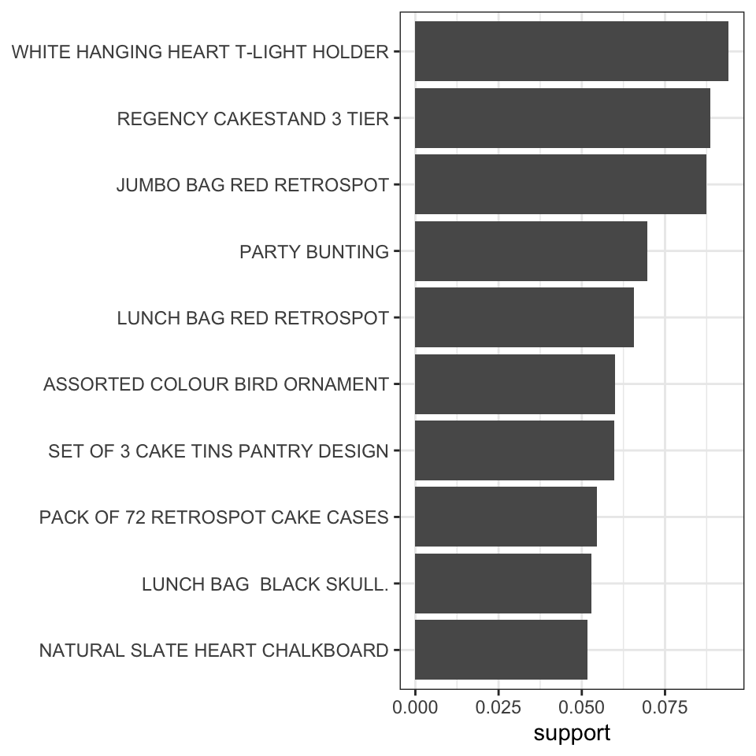

```r
library(arules)

## Get item counts

itemFreq = count(df_clean, Description, sort=TRUE) %>% mutate(support=n/N)

## plot top 10

itemFreq %>% slice(1:10) %>%
  ggplot(aes(fct_reorder(Description, support), support)) + # order bars by n
  geom_col() +         # barplot
  coord_flip() +       # rotate plot 90 deg
  theme(axis.title.y = element_blank()) # remove y axis title
```

```r
print(itemFreq$support[1:10])
```

```
#>  [1] 0.09417 0.08873 0.08734 0.06979 0.06574 0.06001 0.05964 0.05457 0.05297
#> [10] 0.05179
```

## f. Find the *frequent itemsets* that contain at least 3 items and have $s\geq 0.02$. Add the *lift* metric. Show all results, ordered by *lift*.

```r
## Frequent with three items and thresh 0.02

fis = apriori(trans,
               parameter = list(support = .02, minlen=3, target="frequent"))
```

```
#> Apriori
#>
#> Parameter specification:
#>  confidence minval smax arem  aval originalSupport maxtime support minlen
#>          NA    0.1    1 none FALSE            TRUE       5    0.02      3
#>  maxlen            target  ext
#>      10 frequent itemsets TRUE
#>
#> Algorithmic control:
#>  filter tree heap memopt load sort verbose
#>     0.1 TRUE TRUE  FALSE TRUE    2    TRUE
#>
#> Absolute minimum support count: 488
#>
#> set item appearances ...[0 item(s)] done [0.00s].
#> set transactions ...[4211 item(s), 24446 transaction(s)] done [0.07s].
#> sorting and recoding items ... [202 item(s)] done [0.00s].
#> creating transaction tree ... done [0.00s].
#> checking subsets of size 1 2 3 done [0.00s].
#> sorting transactions ... done [0.00s].
#> writing ... [1 set(s)] done [0.00s].
#> creating S4 object  ... done [0.00s].
```

```r
#-- Add lift using the interestMeasure() function

temp=apriori2df(fis) %>%
  mutate(lift = interestMeasure(fis, measure="lift", trans)) %>%
  arrange(-lift)

print(temp)
```

```
#> # A tibble: 1 × 5
#>   items                                  support transIdenticalToIt… count  lift
#>   <chr>                                    <dbl>               <dbl> <int> <dbl>
#> 1 {GREEN REGENCY TEACUP AND SAUCER,PINK…  0.0225            0.000941   549  346.
```

## g. Find all of the *association rules* with $s \geq 0.02$, $c \geq 0.70$. Add the *PS/leverage* and *addedValue* metrics. Show all results, ordered by *addedValue*

```r
## New apriori

fis2 = apriori(trans,
               parameter = list(support = .02, conf=.7, target="rules"))
```

```
#> Apriori
#>
#> Parameter specification:
#>  confidence minval smax arem  aval originalSupport maxtime support minlen
#>         0.7    0.1    1 none FALSE            TRUE       5    0.02      1
#>  maxlen target  ext
#>      10  rules TRUE
#>
#> Algorithmic control:
#>  filter tree heap memopt load sort verbose
#>     0.1 TRUE TRUE  FALSE TRUE    2    TRUE
#>
#> Absolute minimum support count: 488
#>
#> set item appearances ...[0 item(s)] done [0.00s].
#> set transactions ...[4211 item(s), 24446 transaction(s)] done [0.07s].
#> sorting and recoding items ... [202 item(s)] done [0.00s].
#> creating transaction tree ... done [0.00s].
#> checking subsets of size 1 2 3 done [0.00s].
#> writing ... [8 rule(s)] done [0.00s].
#> creating S4 object  ... done [0.00s].
```

```r
#-- Add other interest measures using the interestMeasure() function

temp2=apriori2df(fis2) %>%
  mutate(addedValue = interestMeasure(fis2, measure="addedValue", trans),
         PS=interestMeasure(fis2, measure="leverage",trans)) %>%
  arrange(-addedValue)

print(temp2)
```

```
#> # A tibble: 8 × 9
#>   lhs          rhs     support confidence coverage  lift count addedValue     PS
#>   <chr>        <chr>     <dbl>      <dbl>    <dbl> <dbl> <int>      <dbl>  <dbl>
#> 1 {PINK REGEN… {GREEN…  0.0225      0.894   0.0251  20.7   549      0.851 0.0214
#> 2 {GREEN REGE… {ROSES…  0.0225      0.852   0.0263  18.6   549      0.807 0.0213
#> 3 {PINK REGEN… {GREEN…  0.0263      0.804   0.0328  18.6   644      0.761 0.0249
#> 4 {PINK REGEN… {ROSES…  0.0251      0.767   0.0328  16.7   614      0.721 0.0236
#> 5 {GREEN REGE… {ROSES…  0.0321      0.742   0.0432  16.2   784      0.696 0.0301
#> 6 {GARDENERS … {GARDE…  0.0225      0.718   0.0313  19.0   549      0.680 0.0213
#> # … with 2 more rows
```

## h. Find one rule that you think is interesting. Write the rule and explain why you find it interesting.

I think the Roses Regency Teacup and Saucer -> Green Regency Teacup and Saucer is interesting for objective and subjective reasons. From an objective standpoint, this rule has low support but high confidence, and one of the largest “leverage” measures in the list. This suggests to me that the joint probability of these singleton itemsets surpasses expectations. From a subjective standpoint, I did not expect someone who buys a teacup and saucer to be more likely to buy another one. However, this may tell us something about the kinds of purchasers of regency teacup and saucers. Perhaps these items are rare/vintage, and often purchased by collectors. This would explain the increase in joint purchase prevalence, which defies the intuition behind purchasing teacups/saucers merely for functional purposes (i.e. pouring tea).